# Analisis ARDL SKRIPSI

### 5.4.2 Plot CCF TMA dan TM

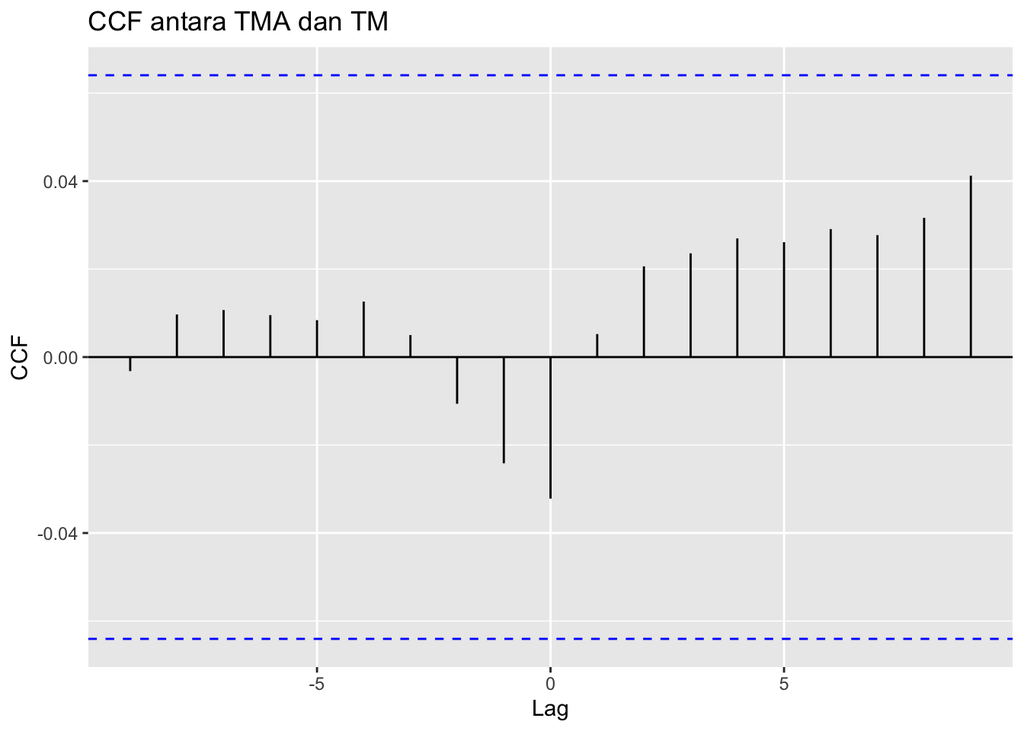

```r
ccf_result2 <- ggCcf(train_2225$TMA, train_2225$TM, lag.max=9, plot = TRUE)+ggtitle("CCF antara TMA dan TM")
ccf_result2
```

### 5.4.3 Plot CCF TMA dan RH

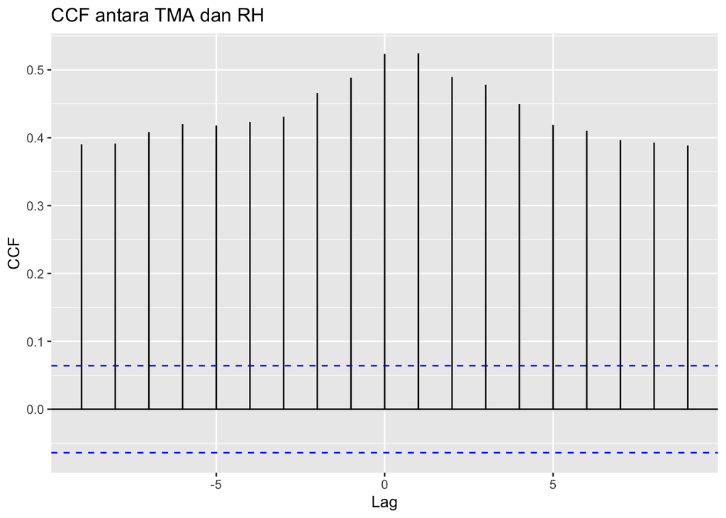

```r
ccf_result3 <- ggCcf(train_2225$TMA, train_2225$RH, lag.max=9, plot = TRUE)+ggtitle("CCF antara TMA dan RH")
ccf_result3
```

### 5.4.4 Plot CCF TMA dan WS

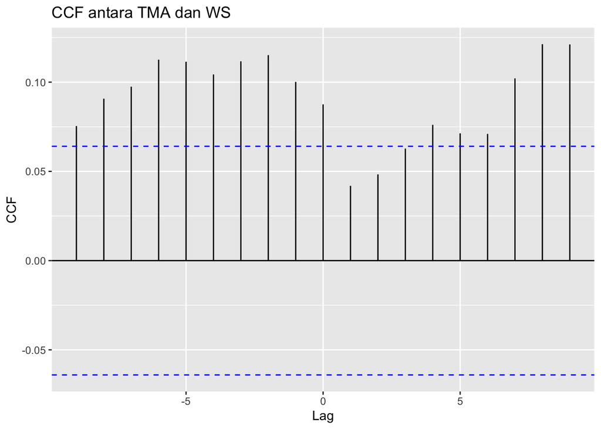

```r
ccf_result4 <- ggCcf(train_2225$TMA, train_2225$WS, lag.max=9, plot = TRUE)+ggtitle("CCF antara TMA dan WS")
ccf_result4
```

### 5.4.5 Plot CCF Gabungan

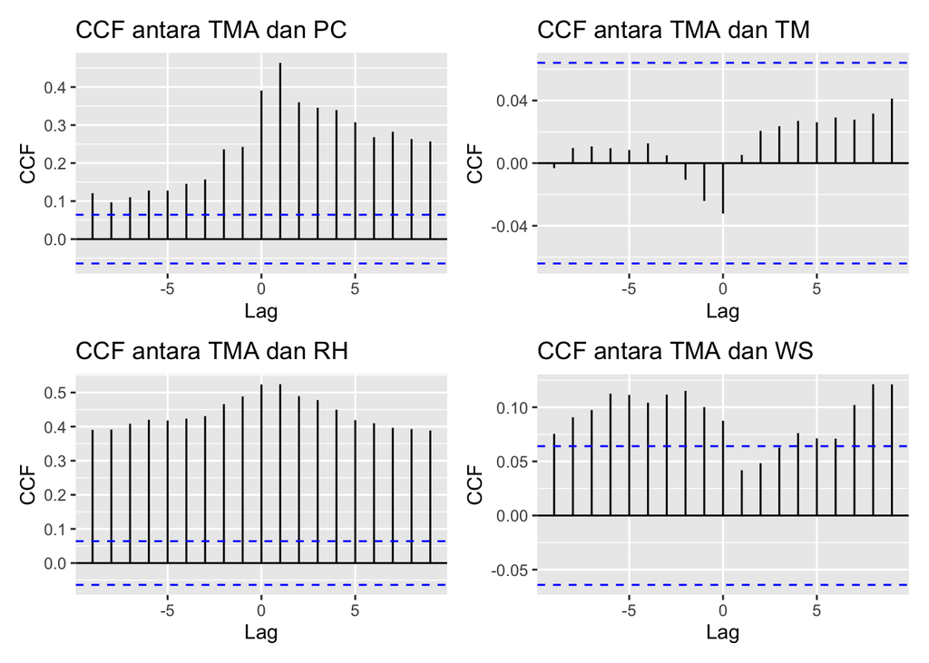

```r
# Menggabungkan plot dalam satu baris
combined_ccf <- ccf_result1 + ccf_result2 + ccf_result3 + ccf_result4

# Mencetak plot gabungan
print(combined_ccf)
```

### 5.4.6 Nilai Korelasi CCF

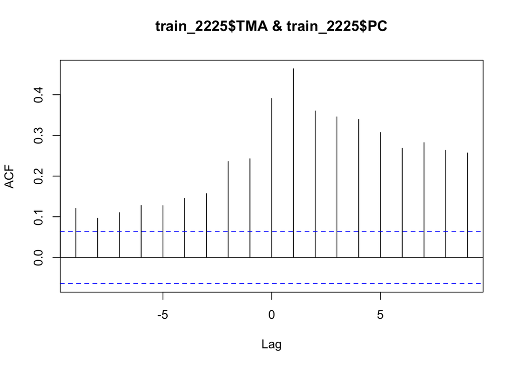

```r
ccf_result1 <- ccf(train_2225$TMA, train_2225$PC, lag.max=9, plot = TRUE)
```

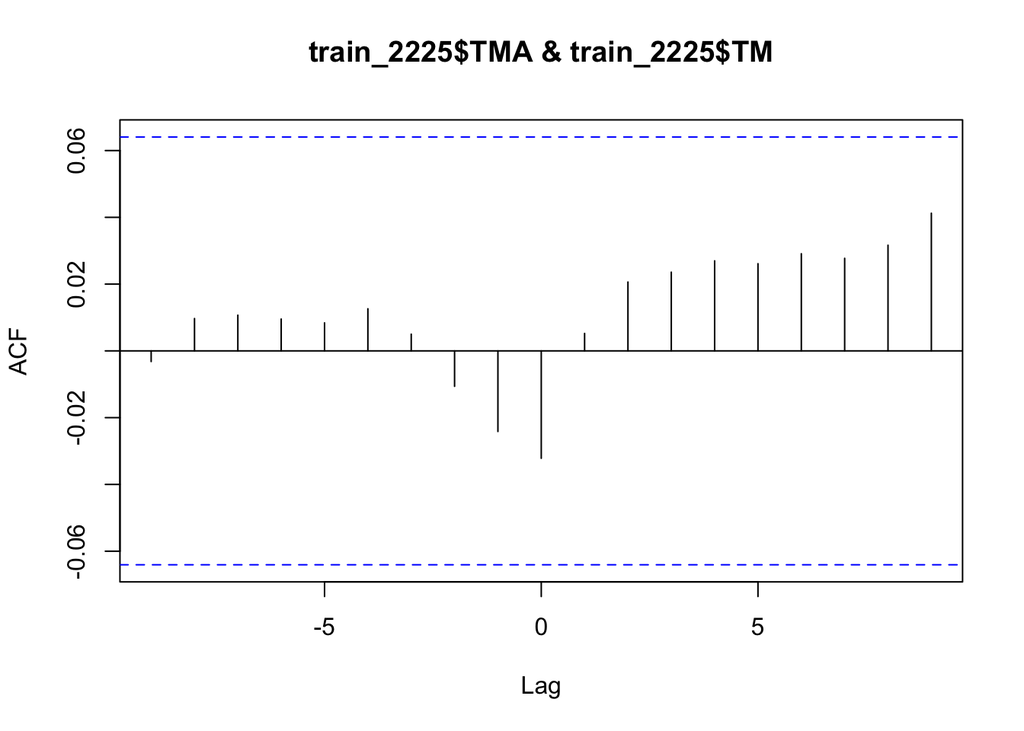

```r
lags1 <- ccf_result1$lag
correlations1 <- ccf_result1$acf

ccf_result2 <- ccf(train_2225$TMA, train_2225$TM, lag.max=9, plot = TRUE)
```

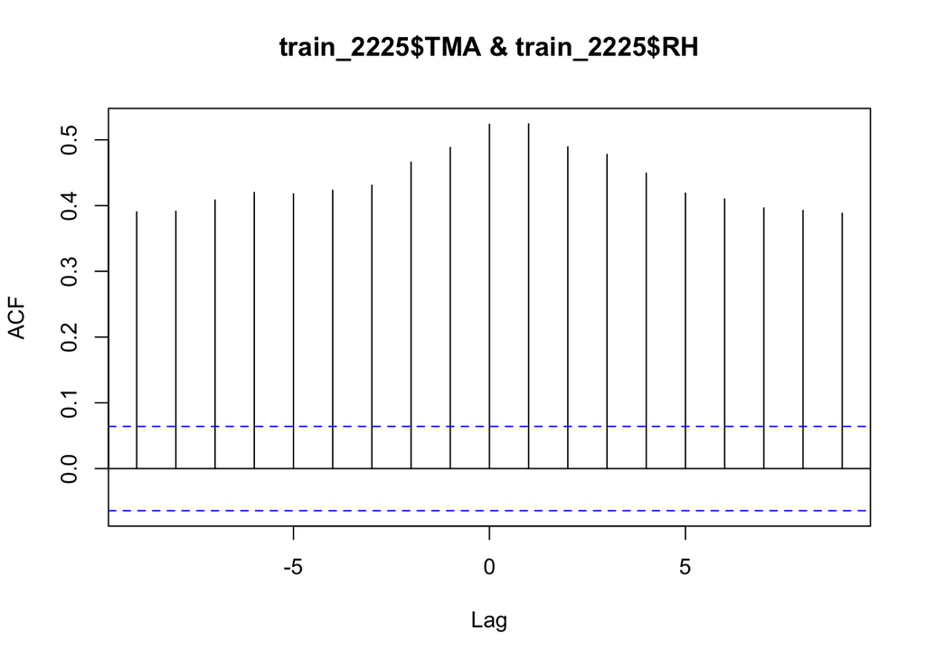

```r
lags2 <- ccf_result2$lag
correlations2 <- ccf_result2$acf

ccf_result3 <- ccf(train_2225$TMA, train_2225$RH, lag.max=9, plot = TRUE)
```

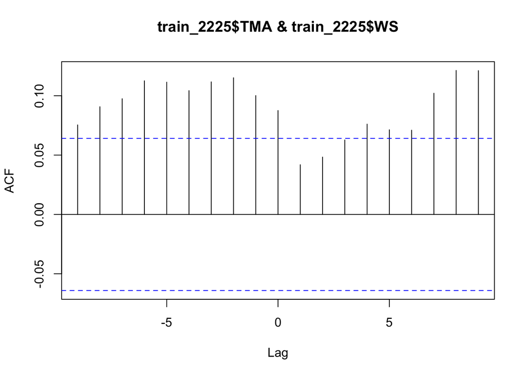

```r
lags3 <- ccf_result3$lag
correlations3 <- ccf_result3$acf

ccf_result4 <- ccf(train_2225$TMA, train_2225$WS, lag.max=9, plot = TRUE)
```

```r
lags4 <- ccf_result4$lag
correlations4 <- ccf_result4$acf

# Buat data frame untuk setiap CCF
ccf_df1 <- data.frame(Lag = lags1, Correlation = correlations1, Pair = "TMA vs PC")
ccf_df2 <- data.frame(Lag = lags2, Correlation = correlations2, Pair = "TMA vs TM")
ccf_df3 <- data.frame(Lag = lags3, Correlation = correlations3, Pair = "TMA vs RH")
ccf_df4 <- data.frame(Lag = lags4, Correlation = correlations4, Pair = "TMA vs WS")

# Gabungkan semua data frame menjadi satu
ccf_all_df <- rbind(ccf_df1, ccf_df2, ccf_df3, ccf_df4)
ccf_all_df
```

```
##    Lag  Correlation      Pair
## 1   -9  0.120786998 TMA vs PC
## 2   -8  0.096569278 TMA vs PC
## 3   -7  0.110186664 TMA vs PC
## 4   -6  0.127797896 TMA vs PC
## 5   -5  0.127379598 TMA vs PC
## 6   -4  0.145128337 TMA vs PC
## 7   -3  0.156873090 TMA vs PC
## 8   -2  0.235956609 TMA vs PC
## 9   -1  0.242654453 TMA vs PC
## 10   0  0.390855812 TMA vs PC
## 11   1  0.463703823 TMA vs PC
## 12   2  0.359976183 TMA vs PC
## 13   3  0.345605259 TMA vs PC
## 14   4  0.339400618 TMA vs PC
```

[output cut: 62 more lines]

# 6 First Difference

## 6.1 Differencing

```r
DTMA <- diff(train_2225$TMA, differences = 1)
DPC <- diff(train_2225$PC, differences = 1)
DTM <- diff(train_2225$TM, differences = 1)
DRH <- diff(train_2225$RH, differences = 1)
DWS <- diff(train_2225$WS, differences = 1)

# Gabungkan dalam dataframe
df <- data.frame(DTMA, DPC, DTM, DRH, DWS)
df.ts<-ts(df)
head(df)
```

```
##         DTMA   DPC   DTM   DRH   DWS
## 1  -7.708333  0.94  0.12  1.75  0.17
## 2  -7.500000 -1.39  0.54 -4.93 -0.69
## 3  -4.375000 -0.18  0.16 -2.91 -0.45
## 4  -1.458333  5.48  0.57  2.87 -0.32
## 5   9.583333  3.75 -0.58  2.39  0.59
## 6 -10.208333  6.72 -0.80  4.06  0.54
```

## 6.2 Plot ACF

### 6.2.1 Plot ACF DTMA

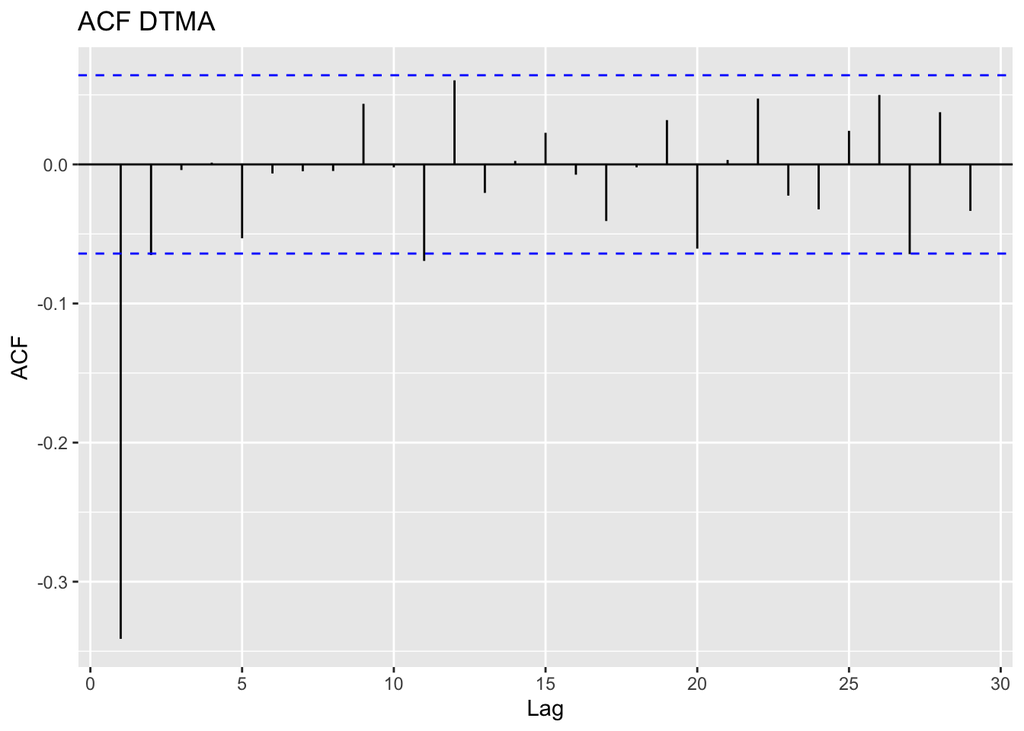

```r
acf_DTMA <- ggAcf(DTMA) + labs(title = "ACF DTMA")
acf_DTMA
```

- Plot ACF DTMA tidak menurun secara perlahan : TMA stasioner

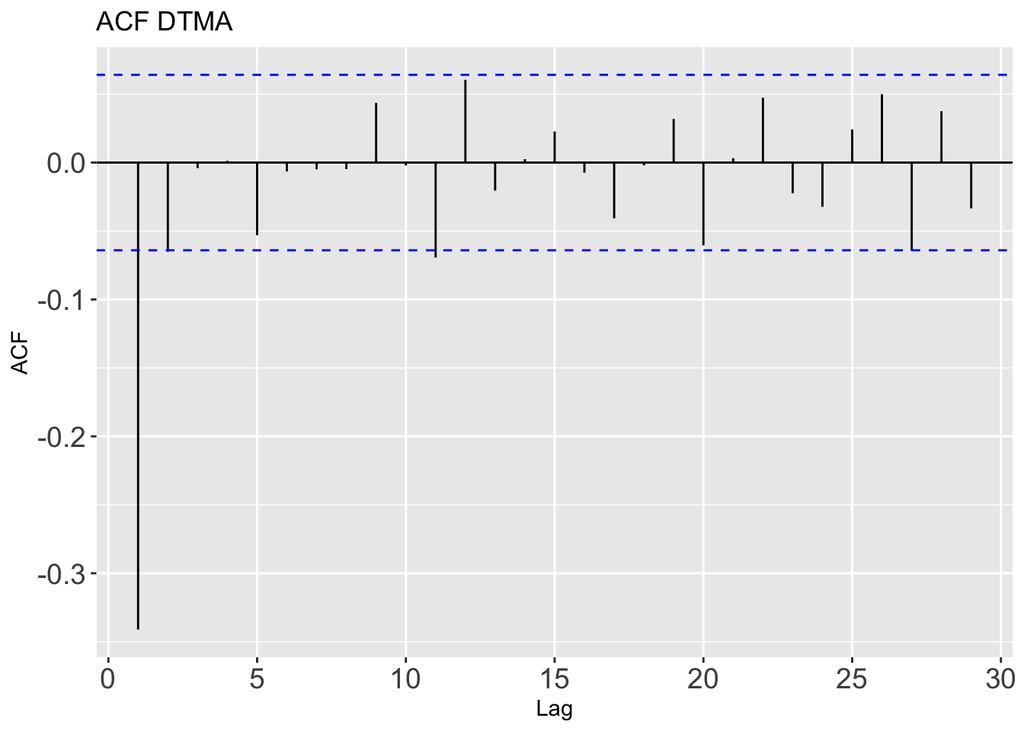

```r
acf_DTMA <- ggAcf(DTMA) +
  labs(title = "ACF DTMA") +
  theme(
    axis.text.x = element_text(size = 14),
    axis.text.y = element_text(size = 14)
  )
acf_DTMA
```

### 6.2.2 Plot ACF DPC

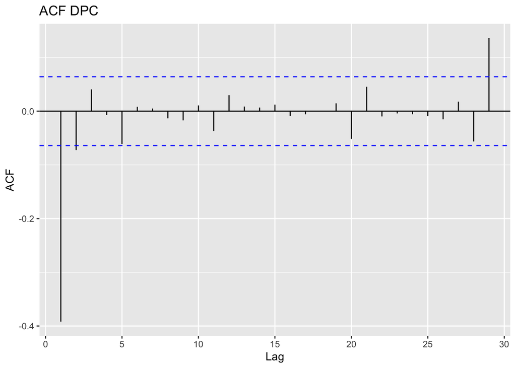

```r
acf_DPC <- ggAcf(DPC) + labs(title = "ACF DPC")
acf_DPC
```

- Plot ACF DPC tidak menurun secara perlahan : PC stasioner

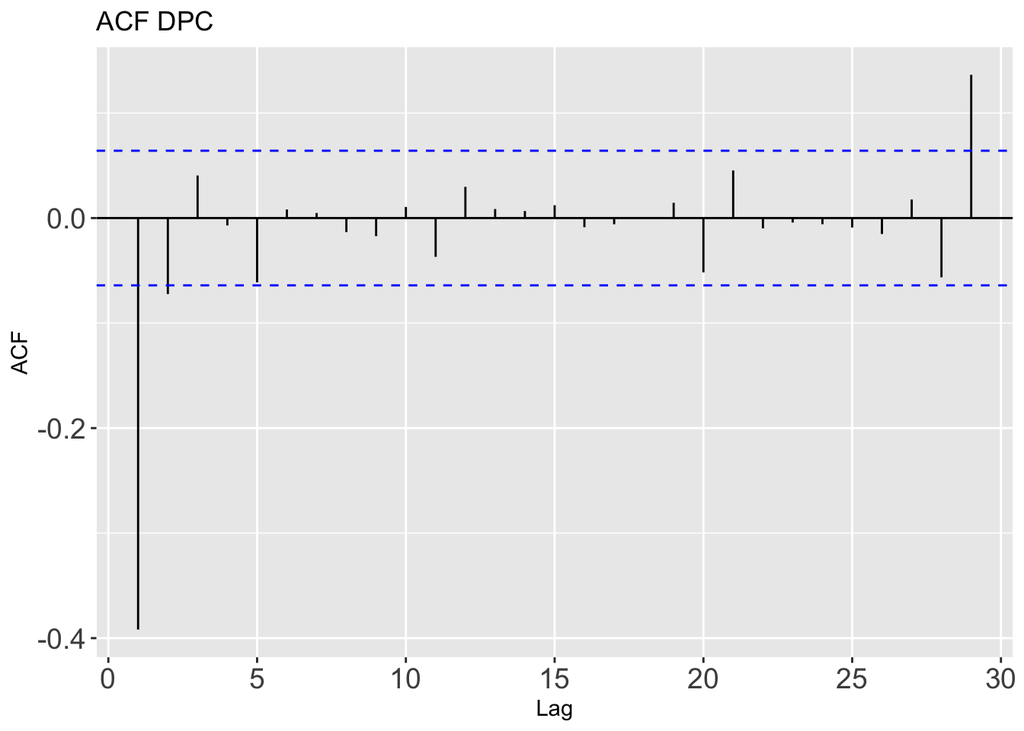

```r
acf_DPC <- ggAcf(DPC) +
  labs(title = "ACF DPC") +
  theme(
    axis.text.x = element_text(size = 14),
    axis.text.y = element_text(size = 14)
  )
acf_DPC
```

### 6.2.3 Plot ACF DTM

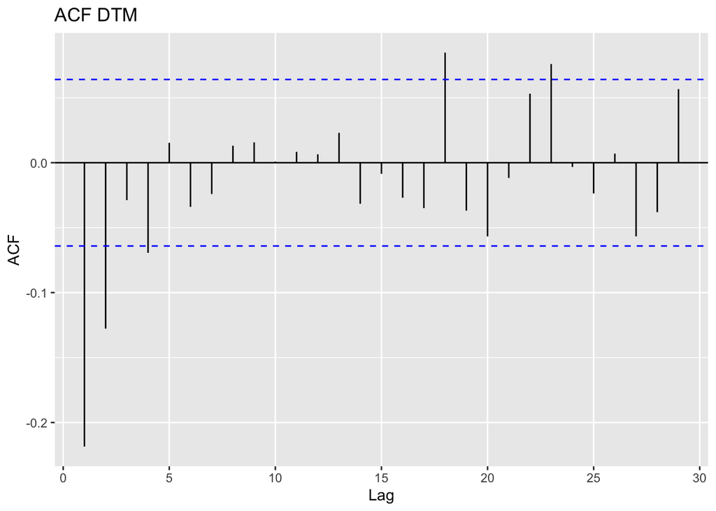

```r
acf_DTM <- ggAcf(DTM) + labs(title = "ACF DTM")
acf_DTM
```

- Plot ACF DTM tidak menurun secara perlahan : TM stasioner

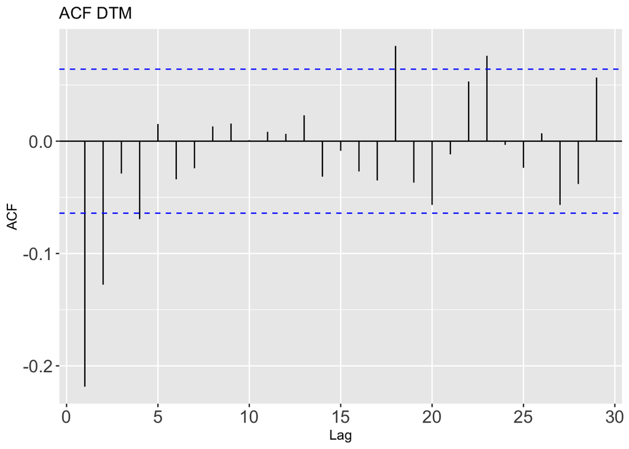

```r
acf_DTM <- ggAcf(DTM) +
  labs(title = "ACF DTM") +
  theme(
    axis.text.x = element_text(size = 14),
    axis.text.y = element_text(size = 14)
  )
acf_DTM
```

### 6.2.4 Plot ACF DRH

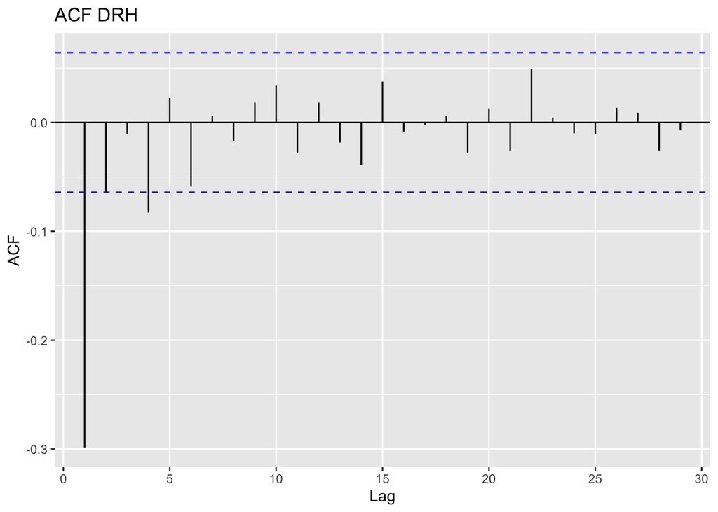

```r
acf_DRH <- ggAcf(DRH) + labs(title = "ACF DRH")
acf_DRH
```

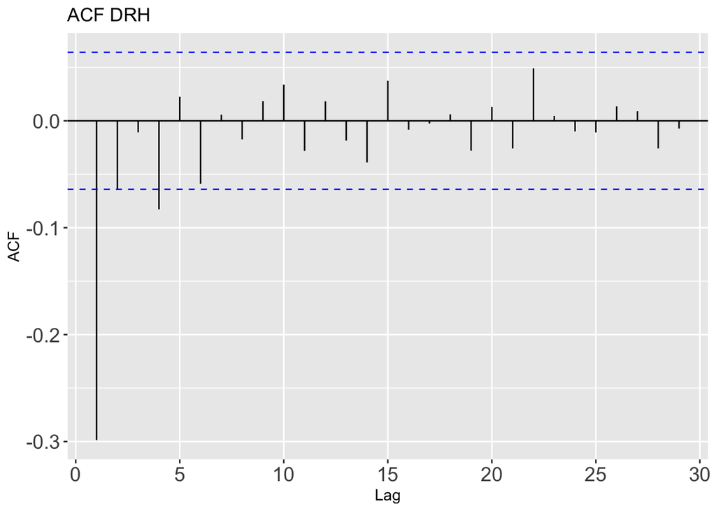

```r
acf_DRH <- ggAcf(DRH) +
  labs(title = "ACF DRH") +
  theme(
    axis.text.x = element_text(size = 14),
    axis.text.y = element_text(size = 14)
  )
acf_DRH
```

### 6.2.5 Plot ACF DWS

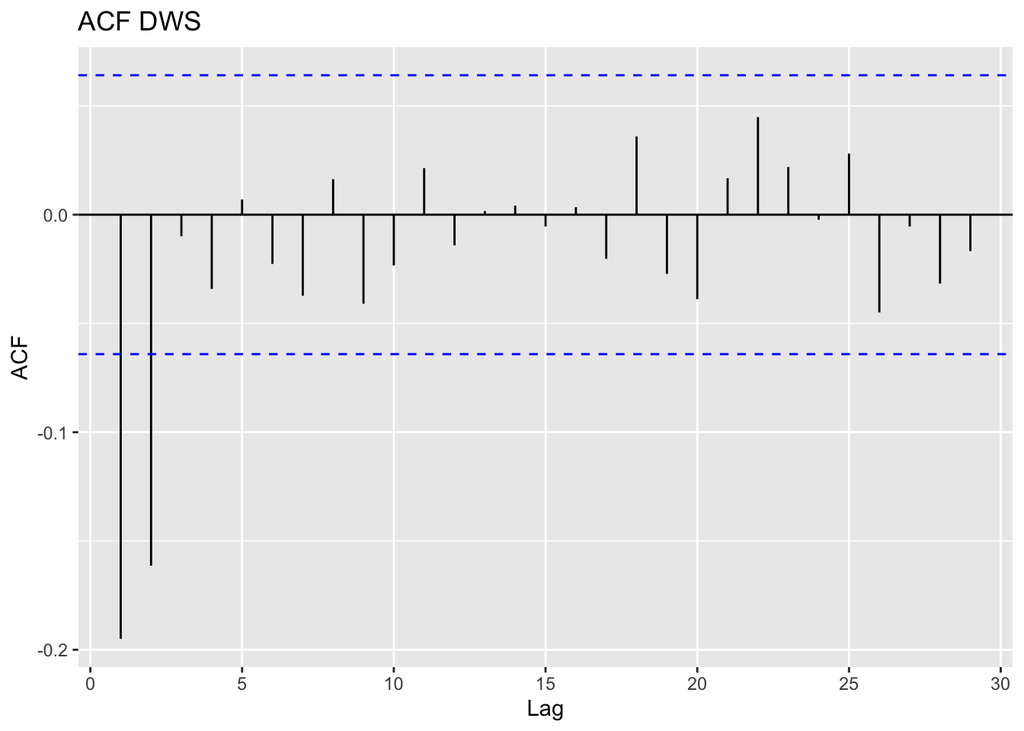

```r
acf_DWS <- ggAcf(DWS) + labs(title = "ACF DWS")
acf_DWS
```

- Plot ACF WS tidak menurun secara perlahan : WS stasioner

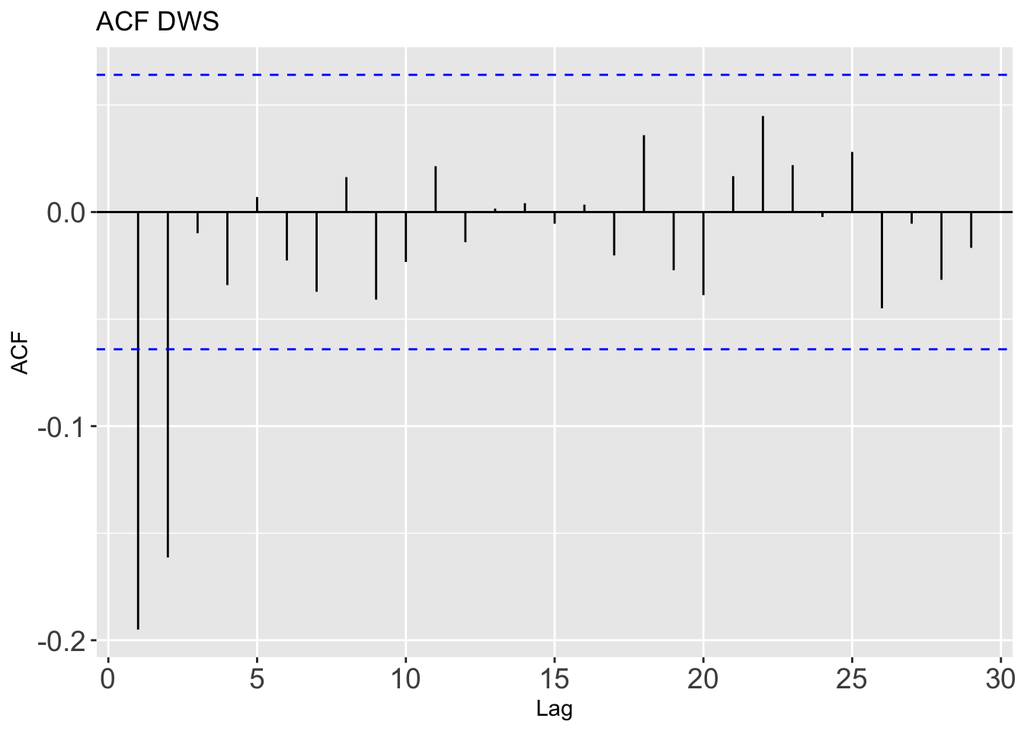

```r
acf_DWS <- ggAcf(DWS) +
  labs(title = "ACF DWS") +
  theme(
    axis.text.x = element_text(size = 14),
    axis.text.y = element_text(size = 14)
  )
acf_DWS
```

### 6.2.6 Plot ACF Gabungan

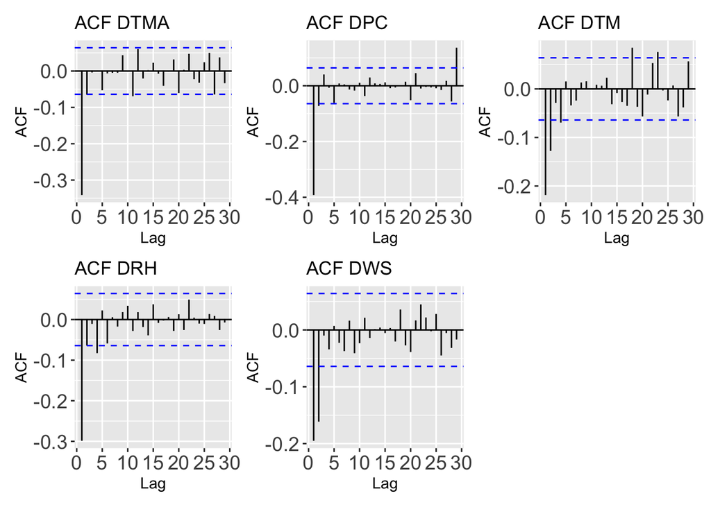

```r
combined_acf <- acf_DTMA + acf_DPC + acf_DTM + acf_DRH + acf_DWS
combined_acf
```

- Semua peubah stasioner pada first difference

## 6.3 Plot PACF

### 6.3.1 Plot PACF DTMA (Lag optimum peubah respon)

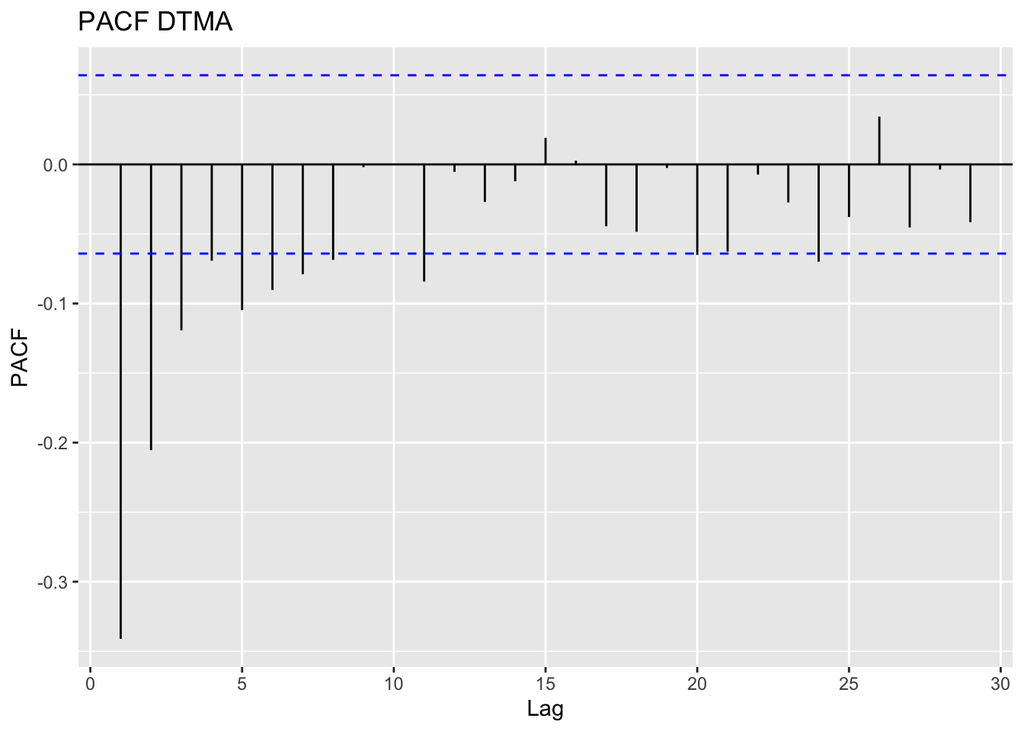

```r
pacf_DTMA <- ggPacf(DTMA) + labs(title = "PACF DTMA")
pacf_DTMA
```

- Lag p antara 1 sampai 8, karena PACF memotong cut-off setelah lag-8

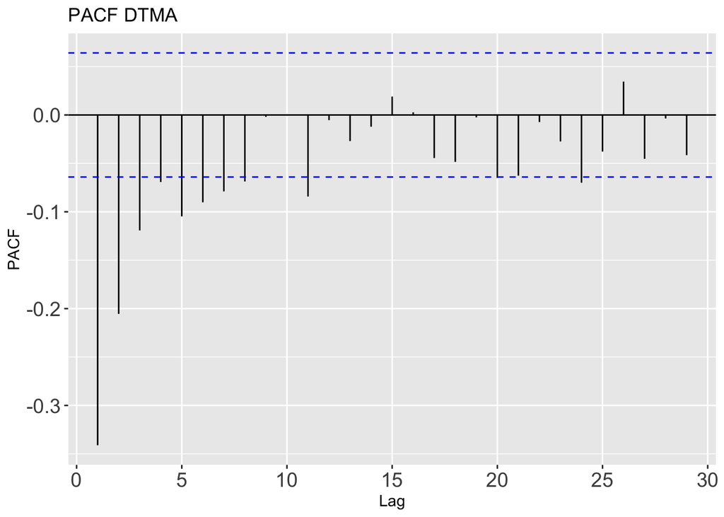

```r
pacf_DTMA <- ggPacf(DTMA) +
  labs(title = "PACF DTMA") +
  theme(
    axis.text.x = element_text(size = 14),
    axis.text.y = element_text(size = 14)
  )
pacf_DTMA
```

### 6.3.2 Plot PACF DPC

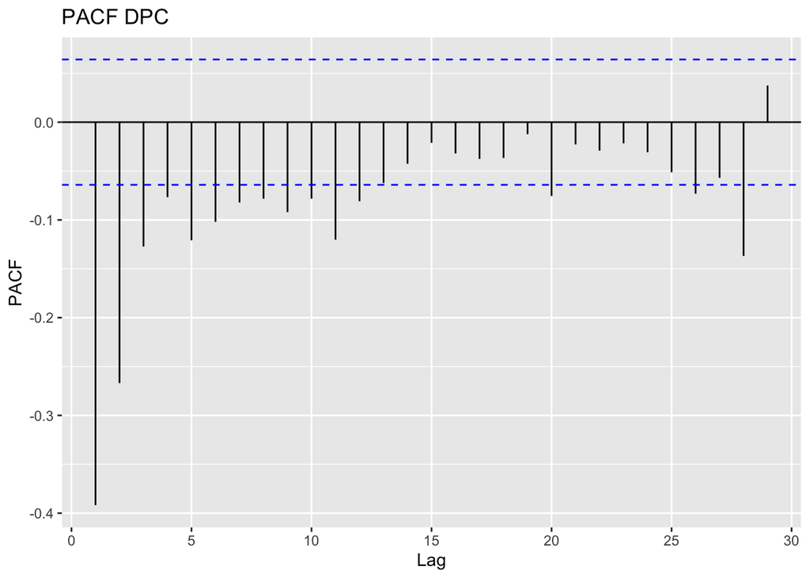

```r
pacf_DPC <- ggPacf(DPC) + labs(title = "PACF DPC")
pacf_DPC
```

### 6.3.3 Plot PACF DTM

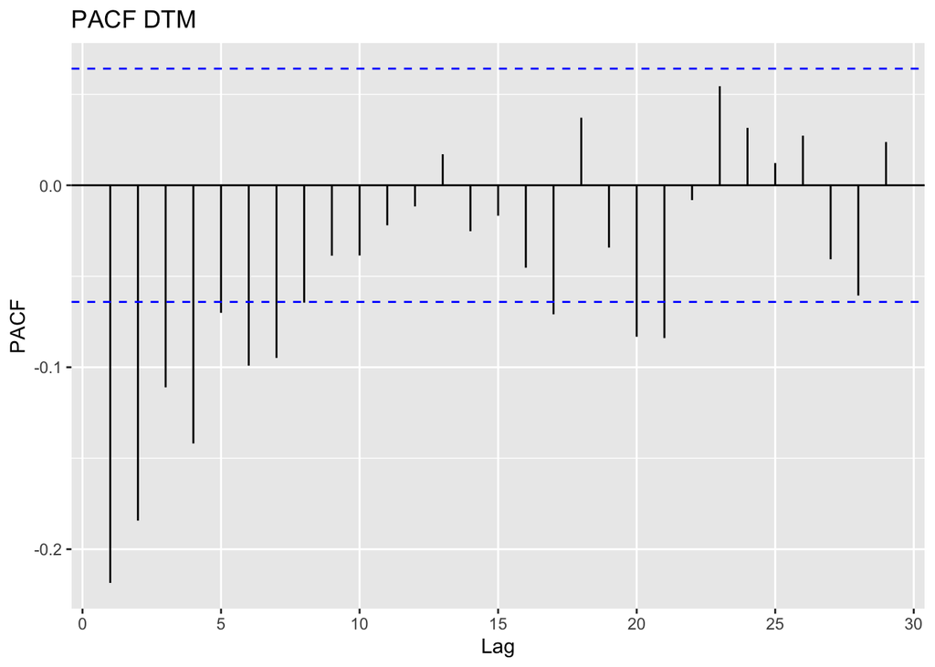

```r
pacf_DTM <- ggPacf(DTM) + labs(title = "PACF DTM")
pacf_DTM
```

### 6.3.4 Plot PACF DRH

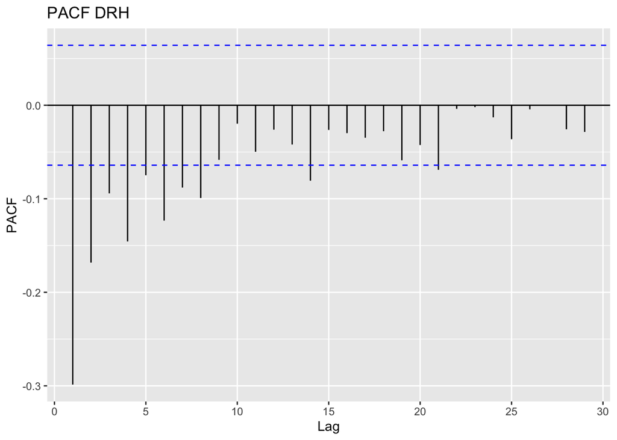

```r
pacf_DRH <- ggPacf(DRH) + labs(title = "PACF DRH")
pacf_DRH
```

### 6.3.5 Plot PACF DWS

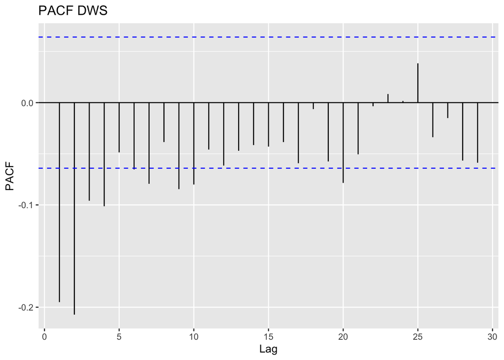

```r
pacf_DWS <- ggPacf(DWS) + labs(title = "PACF DWS")
pacf_DWS
```

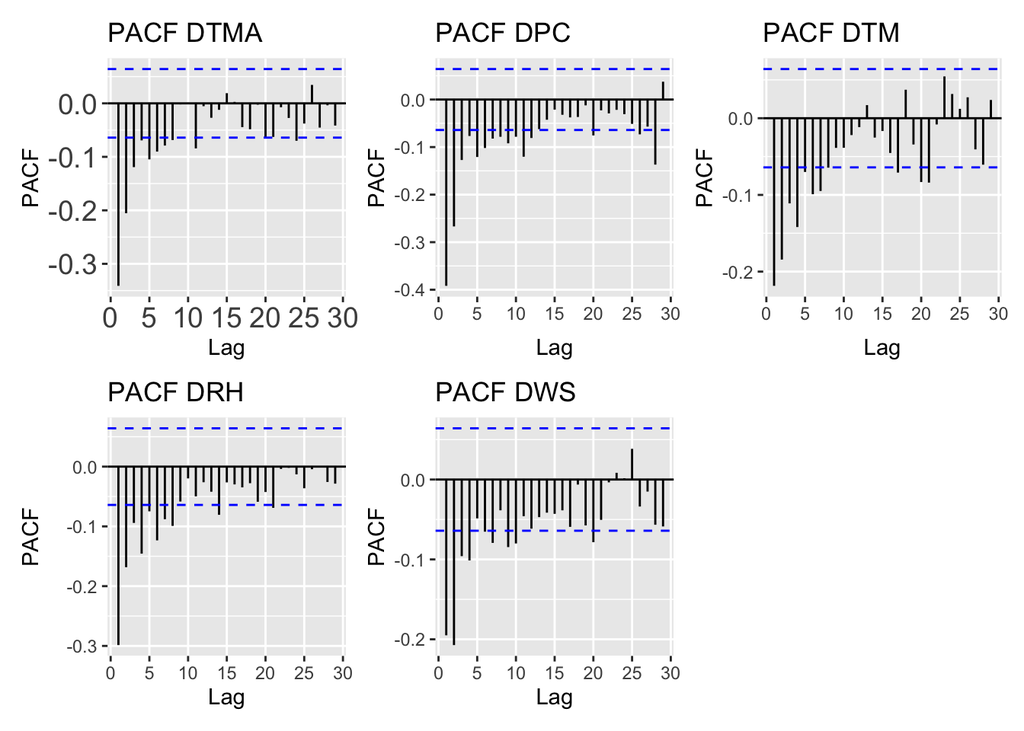

```r
combined_pacf <- pacf_DTMA + pacf_DPC + pacf_DTM + pacf_DRH + pacf_DWS
combined_pacf
```

## 6.4 Uji ADF

### 6.4.1 Uji ADF DTMA

```r
adf.test(DTMA)
```

```
##
##  Augmented Dickey-Fuller Test
##
## data:  DTMA
## Dickey-Fuller = -12.518, Lag order = 9, p-value = 0.01
## alternative hypothesis: stationary
```

- TMA stasioner secara uji formal

### 6.4.2 Uji ADF DPC

```r
adf.test(DPC)
```

```
##
##  Augmented Dickey-Fuller Test
##
## data:  DPC
## Dickey-Fuller = -14.984, Lag order = 9, p-value = 0.01
## alternative hypothesis: stationary
```

- PC stasioner secara uji formal

### 6.4.3 Uji ADF DTM

```r
adf.test(DTM)
```

```
##
##  Augmented Dickey-Fuller Test
##
## data:  DTM
## Dickey-Fuller = -13.44, Lag order = 9, p-value = 0.01
## alternative hypothesis: stationary
```

- TM stasioner secara uji formal

### 6.4.4 Uji ADF DRH

```r
adf.test(DRH)
```

```
##
##  Augmented Dickey-Fuller Test
##
## data:  DRH
## Dickey-Fuller = -13.91, Lag order = 9, p-value = 0.01
## alternative hypothesis: stationary
```

- RH stasioner secara uji formal

### 6.4.5 Uji ADF DWS

```r
adf.test(DWS)
```

```
##
##  Augmented Dickey-Fuller Test
##
## data:  DWS
## Dickey-Fuller = -13.838, Lag order = 9, p-value = 0.01
## alternative hypothesis: stationary
```

- WS stasioner secara uji formal

## 6.5 Plot CCF (Lag optimum peubah penjelas)

### 6.5.1 Plot CCF DTMA dan DPC

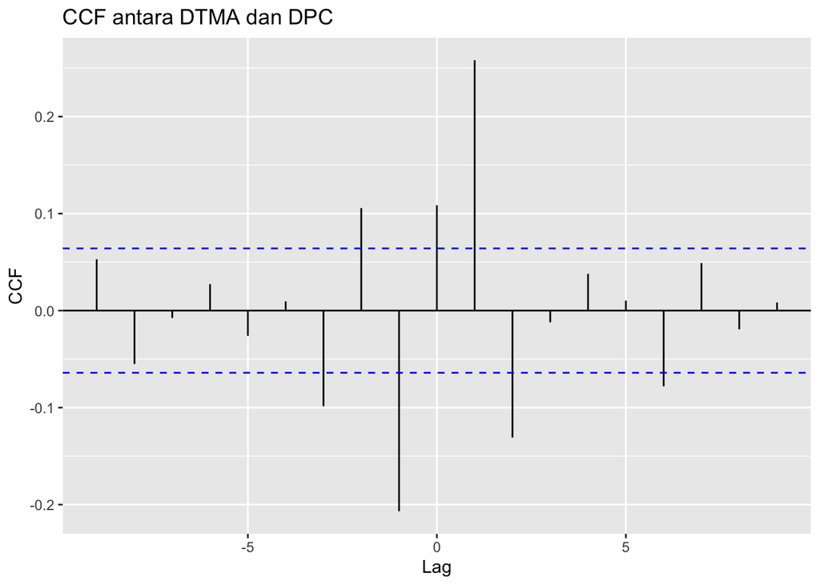

```r
ccf_result1 <- ggCcf(DTMA, DPC, lag.max=9)+ggtitle("CCF antara DTMA dan DPC")
ccf_result1
```

- Lag optimum q1 = 1

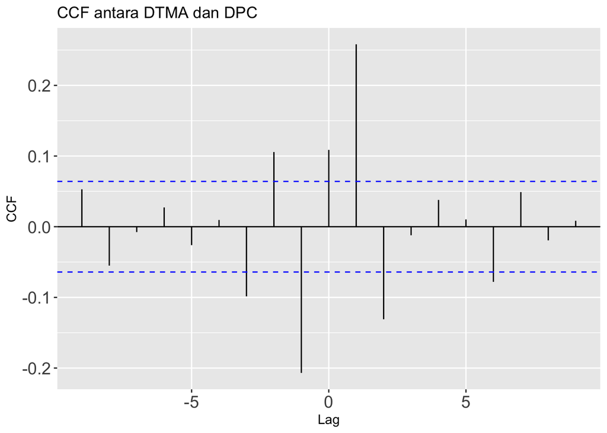

```r
ccf_result1 <- ggCcf(DTMA, DPC, lag.max = 9) +
  ggtitle("CCF antara DTMA dan DPC") +
  theme(
    axis.text.x = element_text(size = 14),  # Besarkan angka di sumbu X
    axis.text.y = element_text(size = 14)   # Besarkan angka di sumbu Y
  )
ccf_result1
```

### 6.5.2 Plot CCF DTMA dan DTM

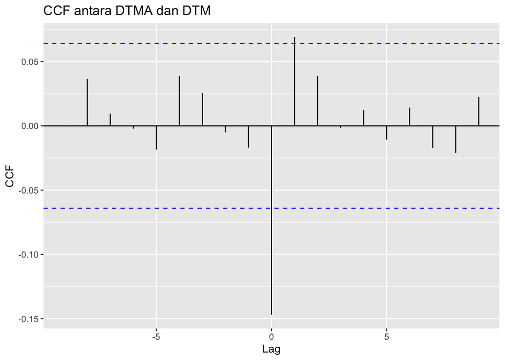

```r
ccf_result2 <- ggCcf(DTMA, DTM, lag.max=9, plot = TRUE)+ggtitle("CCF antara DTMA dan DTM")
ccf_result2
```

- Lag optimum q2 = 1

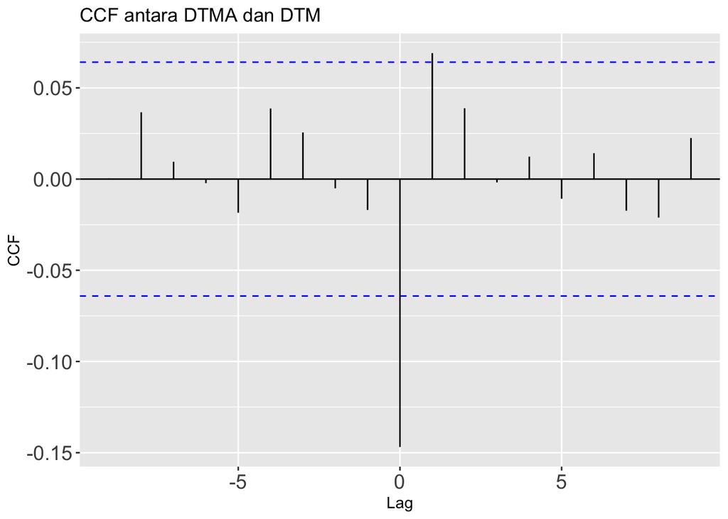

```r
ccf_result1 <- ggCcf(DTMA, DTM, lag.max = 9) +
  ggtitle("CCF antara DTMA dan DTM") +
  theme(
    axis.text.x = element_text(size = 14),  # Besarkan angka di sumbu X
    axis.text.y = element_text(size = 14)   # Besarkan angka di sumbu Y
  )

ccf_result1
```

### 6.5.3 Plot CCF DTMA dan DRH

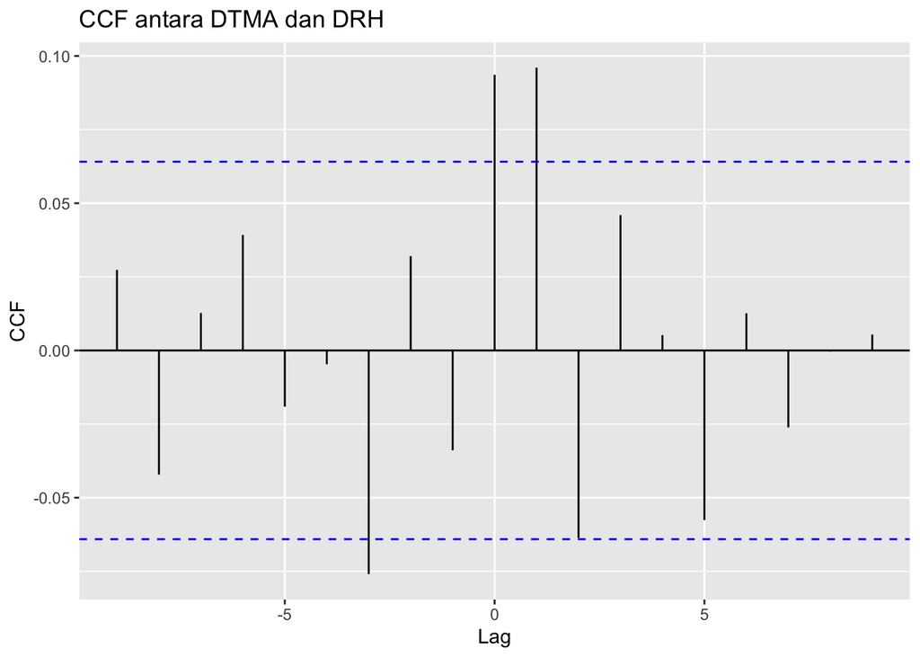

```r
ccf_result3 <- ggCcf(DTMA, DRH, lag.max=9, plot = TRUE)+ggtitle("CCF antara DTMA dan DRH")
ccf_result3
```

- Lag optimum q3 = 1

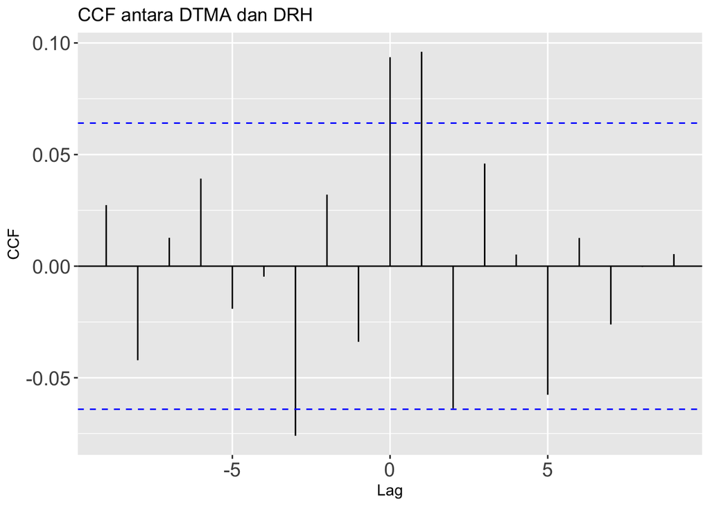

```r
ccf_result1 <- ggCcf(DTMA, DRH, lag.max = 9) +
  ggtitle("CCF antara DTMA dan DRH") +
  theme(
    axis.text.x = element_text(size = 14),  # Besarkan angka di sumbu X
    axis.text.y = element_text(size = 14)   # Besarkan angka di sumbu Y
  )

ccf_result1
```

### 6.5.4 Plot CCF DTMA dan DWS

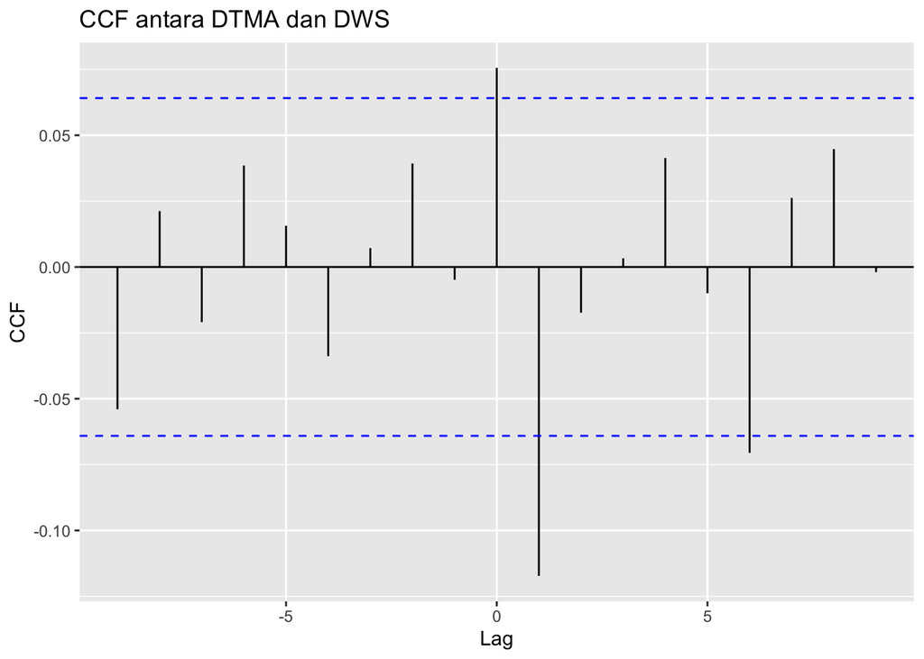

```r
ccf_result4 <- ggCcf(DTMA, DWS, lag.max=9, plot = TRUE)+ggtitle("CCF antara DTMA dan DWS")
ccf_result4
```

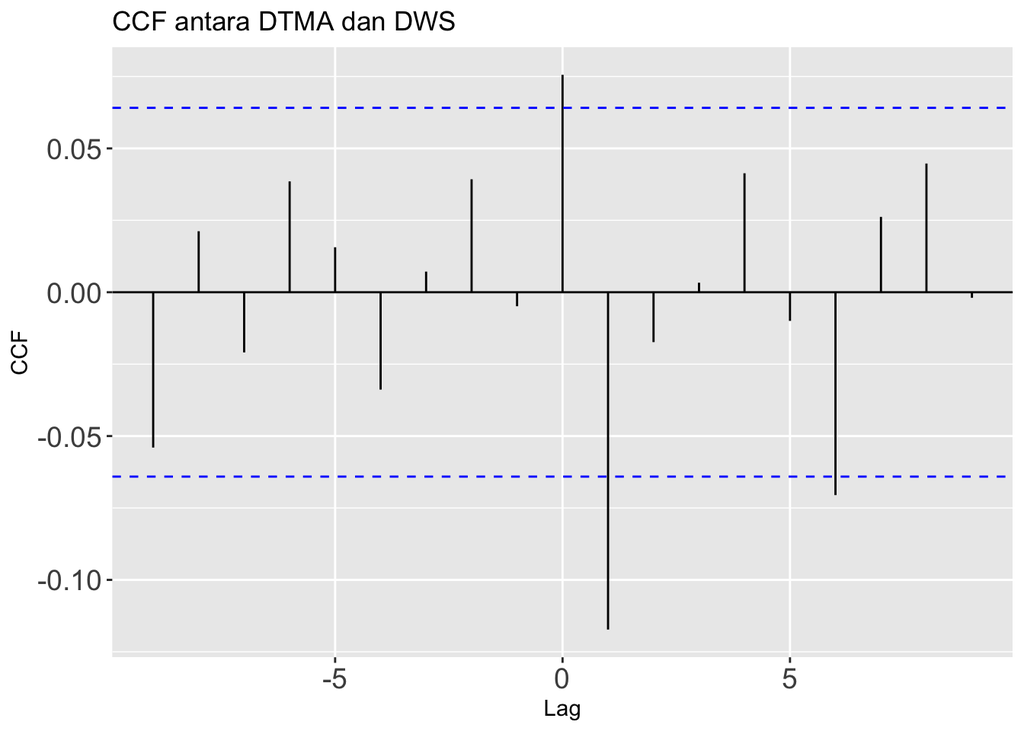

```r
ccf_result1 <- ggCcf(DTMA, DWS, lag.max = 9) +
  ggtitle("CCF antara DTMA dan DWS") +
  theme(
    axis.text.x = element_text(size = 14),  # Besarkan angka di sumbu X
    axis.text.y = element_text(size = 14)   # Besarkan angka di sumbu Y
  )

ccf_result1
```

### 6.5.5 Plot CCF Gabungan

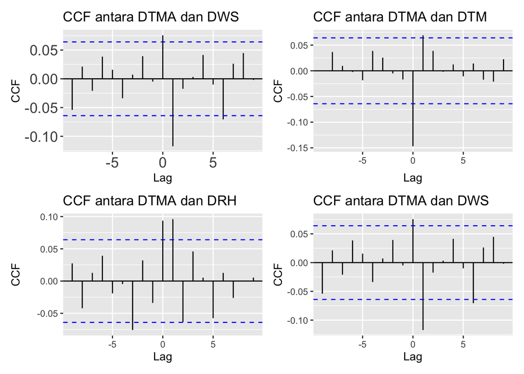

```r
# Menggabungkan plot dalam satu baris
combined_ccf <- ccf_result1 + ccf_result2 + ccf_result3 + ccf_result4

# Mencetak plot gabungan
print(combined_ccf)
```

### 6.5.6 Nilai Korelasi CCF

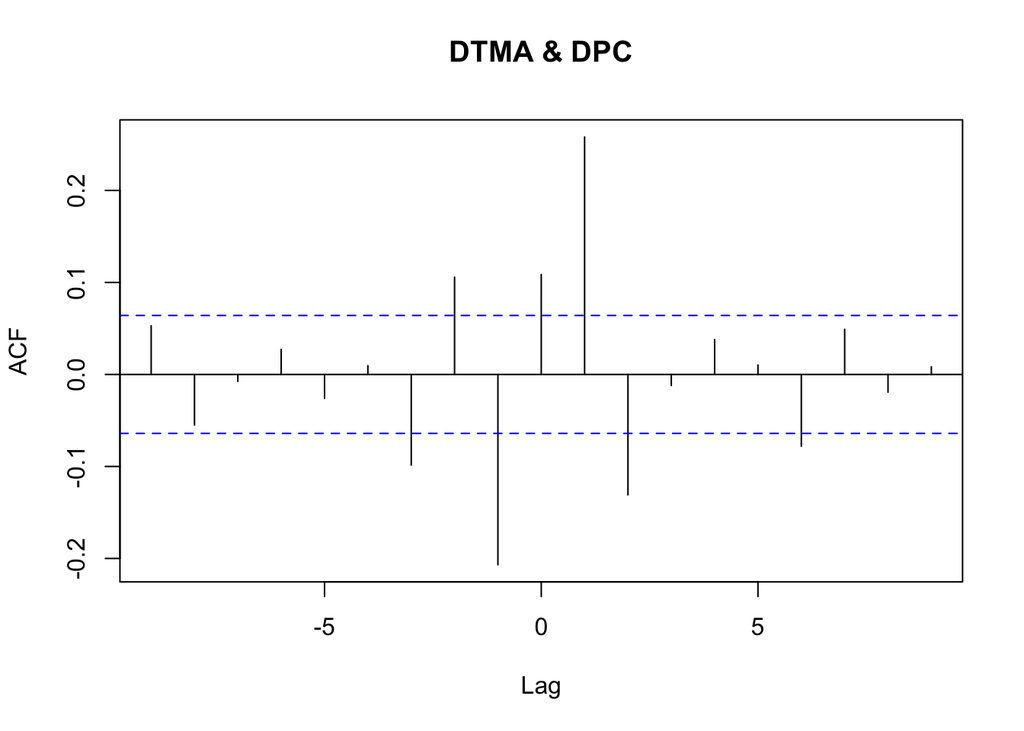

```r
ccf_result1 <- ccf(DTMA, DPC, lag.max=9, plot = TRUE)
```

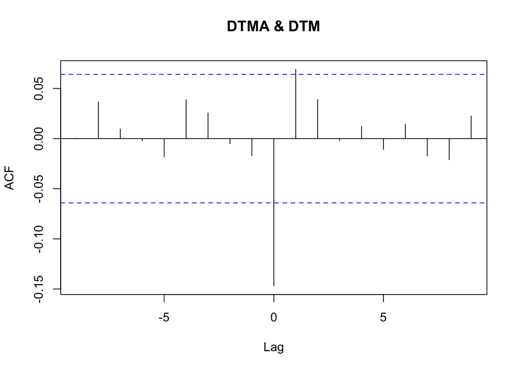

```r
lags1 <- ccf_result1$lag
correlations1 <- ccf_result1$acf

ccf_result2 <- ccf(DTMA, DTM, lag.max=9, plot = TRUE)
```

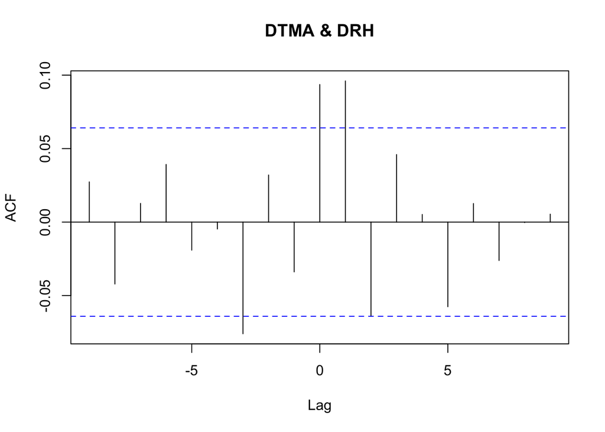

```r
lags2 <- ccf_result2$lag
correlations2 <- ccf_result2$acf

ccf_result3 <- ccf(DTMA, DRH, lag.max=9, plot = TRUE)
```

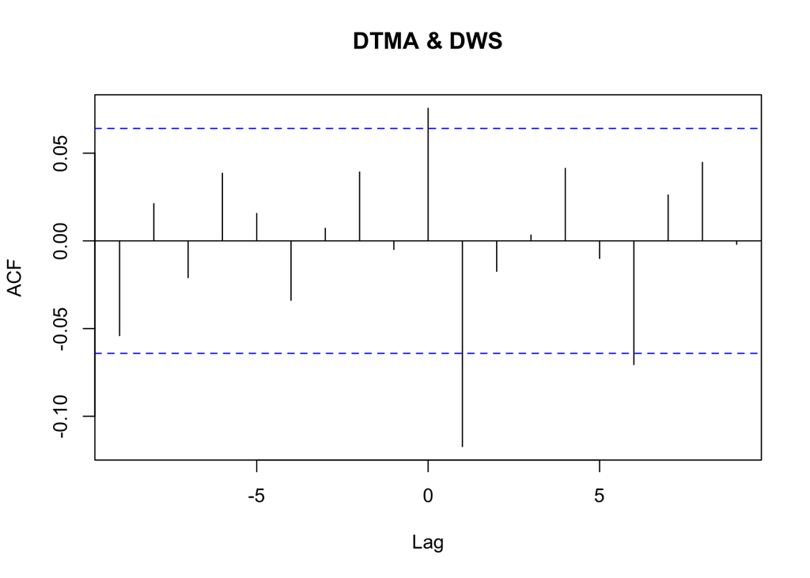

```r
lags3 <- ccf_result3$lag
correlations3 <- ccf_result3$acf

ccf_result4 <- ccf(DTMA, DWS, lag.max=9, plot = TRUE)
```

```r
lags4 <- ccf_result4$lag
correlations4 <- ccf_result4$acf

# Buat data frame untuk setiap CCF
ccf_df1 <- data.frame(Lag = lags1, Correlation = correlations1, Pair = "DTMA vs DPC")
ccf_df2 <- data.frame(Lag = lags2, Correlation = correlations2, Pair = "DTMA vs DTM")
ccf_df3 <- data.frame(Lag = lags3, Correlation = correlations3, Pair = "DTMA vs DRH")
ccf_df4 <- data.frame(Lag = lags4, Correlation = correlations4, Pair = "DTMA vs DWS")

# Gabungkan semua data frame menjadi satu
ccf_all_df <- rbind(ccf_df1, ccf_df2, ccf_df3, ccf_df4)
ccf_all_df
```

```
##    Lag   Correlation        Pair
## 1   -9  0.0529586274 DTMA vs DPC
## 2   -8 -0.0550552403 DTMA vs DPC
## 3   -7 -0.0075649185 DTMA vs DPC
## 4   -6  0.0272775490 DTMA vs DPC
## 5   -5 -0.0260687707 DTMA vs DPC
## 6   -4  0.0095200923 DTMA vs DPC
## 7   -3 -0.0985237382 DTMA vs DPC
## 8   -2  0.1056947588 DTMA vs DPC
## 9   -1 -0.2068571316 DTMA vs DPC
## 10   0  0.1086869199 DTMA vs DPC
## 11   1  0.2580985831 DTMA vs DPC
## 12   2 -0.1309036731 DTMA vs DPC
## 13   3 -0.0120556745 DTMA vs DPC
## 14   4  0.0379023799 DTMA vs DPC
```

[output cut: 62 more lines]

# 7 Dynardl (dynmac)

## 7.1 Uji Kointegrasi

```r
modelbound <- ardlBound(data = train_2225 , formula = TMA ~ PC + TM + RH + WS , case = 2 , max.p = 1, max.q = 9)
```

```
##
## Orders being calculated with max.p = 1 and max.q = 9 ...
##
## Autoregressive order: 10 and p-orders: 2 1 2 2
## ------------------------------------------------------
##
##  Breusch-Godfrey Test for the autocorrelation in residuals:
##
##  Breusch-Godfrey test for serial correlation of order up to 1
##
## data:  modelFull$model
## LM test = 0.071763, df1 = 1, df2 = 903, p-value = 0.7888
##
## ------------------------------------------------------
##
##  Ljung-Box Test for the autocorrelation in residuals:
##
##  Box-Ljung test
##
## data:  res
## X-squared = 0.0024176, df = 1, p-value = 0.9608
##
## ------------------------------------------------------
##
##  Breusch-Pagan Test for the homoskedasticity of residuals:
##
##  studentized Breusch-Pagan test
##
## data:  modelFull$model
## BP = 214.68, df = 21, p-value < 2.2e-16
##
## The p-value of Breusch-Pagan test for the homoskedasticity of residuals:  4.568345e-34 < 0.05!
## ------------------------------------------------------
##
##  Shapiro-Wilk test of normality of residuals:
##
##  Shapiro-Wilk normality test
##
## data:  modelFull$model$residual
## W = 0.89843, p-value < 2.2e-16
```

[output cut: 20 more lines]

```
##
##  ------------------------------------------------------
##  F-statistic note: Asymptotic critical values used.
##
## ------------------------------------------------------
##
##  Ramsey's RESET Test for model specification:
##
##  RESET test
##
## data:  modelECM$model
## RESET = 17.934, df1 = 2, df2 = 907, p-value = 2.298e-08
##
## the p-value of RESET test:  2.298434e-08 < 0.05!
## ------------------------------------------------------
```

```
## ------------------------------------------------------
## Error Correction Model Output:
##
## Time series regression with "ts" data:
## Start = 10, End = 935
##
## Call:
## dynlm(formula = as.formula(model.text), data = data)
##
## Residuals:
##      Min       1Q   Median       3Q      Max
## -122.093  -11.103   -2.706    7.106  127.765
##
## Coefficients:
##        Estimate Std. Error t value Pr(>|t|)
## ec.1   -0.19457    0.01681 -11.572  < 2e-16 ***
## dPC.t   0.61007    0.09090   6.712 3.38e-11 ***
## dPC.1   0.26985    0.09883   2.730 0.006446 **
## dTM.t  -5.62310    1.85577  -3.030 0.002514 **
## dRH.t   0.32264    0.31970   1.009 0.313148
## dRH.1   0.62545    0.29455   2.123 0.033990 *
## dWS.t   0.91139    2.12952   0.428 0.668768
## dWS.1  -3.12533    2.07796  -1.504 0.132918
## dTMA.1 -0.41938    0.02980 -14.073  < 2e-16 ***
## dTMA.2 -0.26556    0.03260  -8.147 1.23e-15 ***
## dTMA.3 -0.18940    0.03338  -5.674 1.87e-08 ***
## dTMA.4 -0.10918    0.03380  -3.230 0.001280 **
## dTMA.5 -0.14097    0.03330  -4.234 2.53e-05 ***
## dTMA.6 -0.11204    0.03336  -3.358 0.000817 ***
## dTMA.7 -0.08664    0.03299  -2.626 0.008773 **
## dTMA.8 -0.03574    0.03188  -1.121 0.262587
## dTMA.9  0.03129    0.02881   1.086 0.277850
## ---
## Signif. codes:  0 '***' 0.001 '**' 0.01 '*' 0.05 '.' 0.1 ' ' 1
##
## Residual standard error: 20.8 on 909 degrees of freedom
## Multiple R-squared:  0.3986, Adjusted R-squared:  0.3874
## F-statistic: 35.44 on 17 and 909 DF,  p-value: < 2.2e-16
##
## ------------------------------------------------------
## Long-run coefficients:
##      TMA.1       PC.1       TM.1       RH.1       WS.1
## -0.1945720  1.1873397  2.1515572  0.7212944 -3.4382789
##
```

## 7.2 Model

### 7.2.1 Jangka Pendek

```r
modelardl <- dynardl(
  DTMA ~ DPC + DTM + DRH + DWS,
  data = df,
  lags = list(
    "DTMA" = 1:9,
    "DPC" = 1,
    "DTM" = 1,
    "DRH" = 1,
    "DWS" = 1
  ),
  ec = TRUE
)
```

```
## [1] "Error correction (EC) specified; dependent variable to be run in differences."
```

```r
summary(modelardl)
```

```
##
## Call:
## lm(formula = as.formula(paste(paste(dvnamelist), "~", paste(colnames(IVs),
##     collapse = "+"), collapse = " ")))
##
## Residuals:
##     Min      1Q  Median      3Q     Max
## -82.826 -12.158  -3.242   7.667 141.247
##
## Coefficients:
##             Estimate Std. Error t value Pr(>|t|)
## (Intercept)  0.07491    0.74754   0.100 0.920206
## l.1.DTMA    -1.46652    0.03180 -46.113  < 2e-16 ***
## l.2.DTMA    -0.24857    0.03542  -7.017 4.42e-12 ***
## l.3.DTMA    -0.19902    0.03596  -5.534 4.08e-08 ***
## l.4.DTMA    -0.11395    0.03658  -3.115 0.001896 **
## l.5.DTMA    -0.16067    0.03620  -4.438 1.02e-05 ***
## l.6.DTMA    -0.11939    0.03631  -3.288 0.001048 **
## l.7.DTMA    -0.09846    0.03595  -2.739 0.006279 **
## l.8.DTMA    -0.05481    0.03466  -1.581 0.114112
## l.9.DTMA     0.02475    0.03147   0.786 0.431807
## l.1.DPC      0.71957    0.08740   8.233 6.27e-16 ***
## l.1.DTM      5.30432    2.02740   2.616 0.009035 **
## l.1.DRH      1.23941    0.33633   3.685 0.000242 ***
## l.1.DWS     -5.57795    2.28050  -2.446 0.014636 *
## ---
## Signif. codes:  0 '***' 0.001 '**' 0.01 '*' 0.05 '.' 0.1 ' ' 1
##
## Residual standard error: 22.75 on 912 degrees of freedom
##   (9 observations deleted due to missingness)
## Multiple R-squared:  0.7311, Adjusted R-squared:  0.7272
## F-statistic: 190.7 on 13 and 912 DF,  p-value: < 2.2e-16
```

```r
AIC(modelardl$model)
```

```
## [1] 8430.246
```

### 7.2.2 Jangka Panjang

```r
modelardll <- dynardl(
  formula = TMA ~ PC + TM + RH + WS,
  data = train_2225,
  levels = c("PC", "TM", "RH", "WS"),
  ec = FALSE,
)
```

```
## [1] "Dependent variable to be run in levels."
```

```r
summary(modelardll)
```

```
##
## Call:
## lm(formula = as.formula(paste(paste(dvnamelist), "~", paste(colnames(IVs),
##     collapse = "+"), collapse = " ")))
##
## Residuals:
##     Min      1Q  Median      3Q     Max
## -80.358 -12.724  -2.545   8.965 136.162
##
## Coefficients:
##              Estimate Std. Error t value Pr(>|t|)
## (Intercept) -37.02341   38.06871  -0.973 0.331034
## l.1.TMA       0.66636    0.02215  30.083  < 2e-16 ***
## PC            0.79921    0.09555   8.364  < 2e-16 ***
## TM            4.16986    1.08777   3.833 0.000135 ***
## RH            1.60188    0.24077   6.653 4.89e-11 ***
## WS           -1.01645    1.66020  -0.612 0.540524
## ---
## Signif. codes:  0 '***' 0.001 '**' 0.01 '*' 0.05 '.' 0.1 ' ' 1
##
## Residual standard error: 23.13 on 929 degrees of freedom
##   (1 observation deleted due to missingness)
## Multiple R-squared:  0.685,  Adjusted R-squared:  0.6833
## F-statistic:   404 on 5 and 929 DF,  p-value: < 2.2e-16
```

```r
AIC(modelardll$model)
```

```
## [1] 8535.643
```

## 7.3 Uji Asumsi

### 7.3.1 Uji autokorelasi residual (Box-Ljung Test)

```r
res1 <- residuals(modelardl$model)
Box.test(res1, lag = 20, type = "Ljung-Box")
```

```
##
##  Box-Ljung test
##
## data:  res1
## X-squared = 18.308, df = 20, p-value = 0.5671
```

Hipotesis: H₀ (nol): Tidak ada autokorelasi dalam residual.

H₁ (alternatif): Terdapat autokorelasi dalam residual.

Kesimpulan: p-value = 0.5671 (>0.05) tak tolak H₀, tidak ada bukti signifikan autokorelasi dalam residual model.

### 7.3.2 Uji Normalitas (Jarque-Bera Test)

```r
jarque.bera.test(res1)
```

```
##
##  Jarque Bera Test
##
## data:  res1
## X-squared = 1239.1, df = 2, p-value < 2.2e-16
```

Hipotesis: H₀ (nol): Data residual berdistribusi normal.

H₁ (alternatif): Data residual tidak berdistribusi normal.

Kesimpulan: p-value = < 2.2e-16 (< 0.05), tolak H₀, residual tidak berdistribusi normal.

### 7.3.3 Uji Heteroskedastisitas (Breusch-Pagan Test)

```r
fitted_val1 <- fitted(modelardl$model)
bptest(res1 ~ fitted_val1)
```

```
##
##  studentized Breusch-Pagan test
##
## data:  res1 ~ fitted_val1
## BP = 0.62528, df = 1, p-value = 0.4291
```

Hipotesis: H₀ (nol): Residual memiliki varians yang konstan (homoskedastis).

H₁ (alternatif): Residual memiliki varians yang tidak konstan (heteroskedastis).

Kesimpulan: p-value = 0.4291 (> 0.05), tak tolak H₀, residual memiliki varians yang konstan (homoskedastis)

### 7.3.4 Multikolinearitas

```r
vif(modelardl$model)
```

```
## l.1.DTMA l.2.DTMA l.3.DTMA l.4.DTMA l.5.DTMA l.6.DTMA l.7.DTMA l.8.DTMA
## 1.278786 1.587273 1.636188 1.693114 1.658713 1.668620 1.635194 1.520474
## l.9.DTMA  l.1.DPC  l.1.DTM  l.1.DRH  l.1.DWS
## 1.253834 1.172397 1.475608 1.428249 1.157622
```

## 7.4 Forecasting

### 7.4.1 Data Training

```r
# Differencing
DTMA <- diff(train_2225$TMA, differences = 1)
DPC  <- diff(train_2225$PC, differences = 1)
DTM  <- diff(train_2225$TM, differences = 1)
DRH  <- diff(train_2225$RH, differences = 1)
DWS  <- diff(train_2225$WS, differences = 1)

# Gabungkan menjadi data.frame
train_baru <- data.frame(DPC, DTM, DRH, DWS)
colnames(train_baru) <- c("DPC", "DTM", "DRH", "DWS")
```

```r
coefs <- summary(modelardl)$coefficients

intercept <- coefs["(Intercept)", "Estimate"]
b1 <- coefs["l.1.DPC", "Estimate"]
b2 <- coefs["l.1.DTM", "Estimate"]
b3 <- coefs["l.1.DRH", "Estimate"]
b4 <- coefs["l.1.DWS", "Estimate"]
```

```r
train_baru$DTMA_pred <- intercept +
  b1 * train_baru$DPC +
  b2 * train_baru$DTM +
  b3 * train_baru$DRH +
  b4 * train_baru$DWS
```

```r
# TMA ke-n = TMA ke-(n-1) + delta TMA ke-n
train_baru$TMA_pred <- NA
train_baru$TMA_pred[1] <- train_2225$TMA[1] + train_baru$DTMA_pred[1]

for(i in 2:nrow(train_baru)) {
  train_baru$TMA_pred[i] <- train_baru$TMA_pred[i-1] + train_baru$DTMA_pred[i]
}
```

```r
TMA_actual <- train_2225$TMA[-1]  # karena ada differencing
TMA_pred <- train_baru$TMA_pred
```

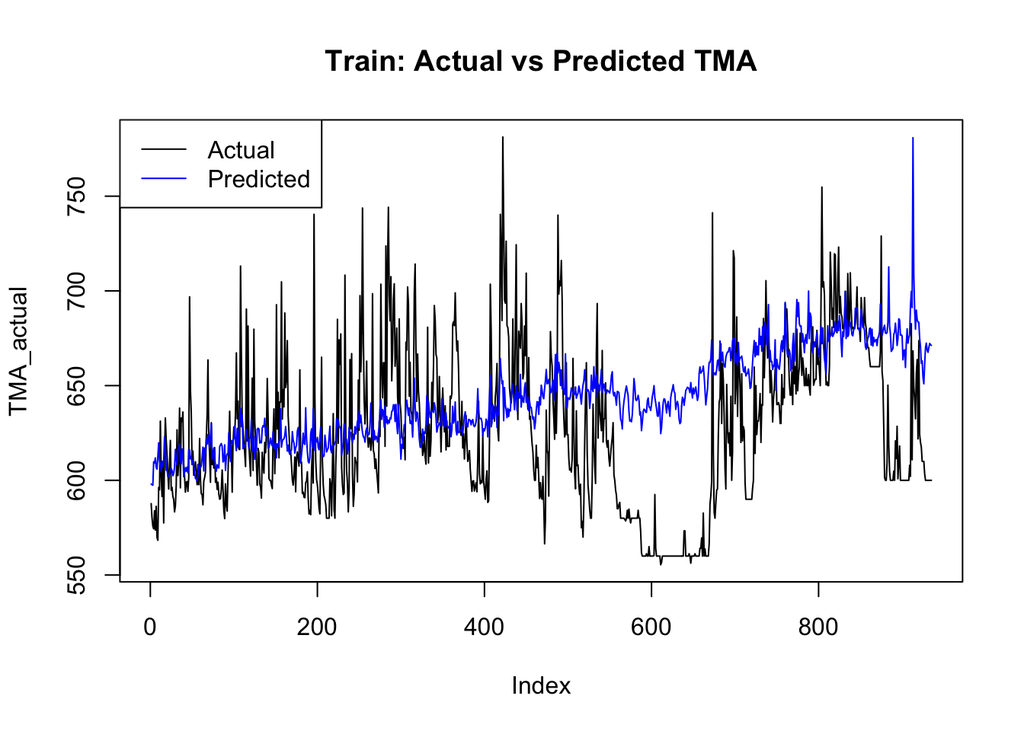

```r
plot(TMA_actual, type = "l", col = "black", main = "Train: Actual vs Predicted TMA")
lines(TMA_pred, col = "blue")
legend("topleft", legend = c("Actual", "Predicted"), col = c("black", "blue"), lty = 1)
```

```r
# Evaluasi
MAE <- mean(abs(TMA_pred - TMA_actual), na.rm = TRUE)
RMSE <- sqrt(mean((TMA_pred - TMA_actual)^2, na.rm = TRUE))
MAPE <- mean(abs((TMA_actual - TMA_pred) / TMA_actual), na.rm = TRUE) * 100

cat("MAE:", MAE, "\n")
```

```
## MAE: 33.81858
```

```r
cat("RMSE:", RMSE, "\n")
```

```
## RMSE: 43.18006
```

```r
cat("MAPE:", MAPE, "%\n")
```

```
## MAPE: 5.514768 %
```

### 7.4.2 Data testing

```r
str(test_2225)
```

```
## tibble [160 × 7] (S3: tbl_df/tbl/data.frame)
##  $ Date    : POSIXct[1:160], format: "2024-07-25" "2024-07-26" ...
##  $ TMA     : num [1:160] 600 600 600 600 600 ...
##  $ TM      : num [1:160] 24.4 24.9 24.9 24.7 24.5 ...
##  $ PC      : num [1:160] 0.01 0.01 0 0 0 ...
##  $ RH      : num [1:160] 85.3 84.4 82.3 82.3 81.6 ...
##  $ WS      : num [1:160] 1.32 1.13 1.24 1.01 1.16 1.35 1.25 1.01 0.98 0.99 ...
##  $ DataType: chr [1:160] "Test" "Test" "Test" "Test" ...
```

```r
summary(test_2225)
```

```
##       Date                          TMA              TM              PC
##  Min.   :2024-07-25 00:00:00   Min.   :590.0   Min.   :23.71   Min.   : 0.000
##  1st Qu.:2024-09-02 18:00:00   1st Qu.:599.6   1st Qu.:24.93   1st Qu.: 0.145
##  Median :2024-10-12 12:00:00   Median :618.2   Median :25.43   Median : 2.150
##  Mean   :2024-10-12 12:00:00   Mean   :620.5   Mean   :25.48   Mean   : 6.256
##  3rd Qu.:2024-11-21 06:00:00   3rd Qu.:640.0   3rd Qu.:26.03   3rd Qu.: 8.732
##  Max.   :2024-12-31 00:00:00   Max.   :744.0   Max.   :27.06   Max.   :74.460
##        RH              WS          DataType
##  Min.   :71.24   Min.   :0.660   Length:160
##  1st Qu.:80.47   1st Qu.:1.087   Class :character
##  Median :82.84   Median :1.270   Mode  :character
##  Mean   :83.08   Mean   :1.474
##  3rd Qu.:86.55   3rd Qu.:1.583
##  Max.   :93.96   Max.   :3.390
```

```r
TDPC <- diff(test_2225$PC, differences = 1)
TDTM <- diff(test_2225$TM, differences = 1)
TDRH <- diff(test_2225$RH, differences = 1)
TDWS <- diff(test_2225$WS, differences = 1)

test_baru <- data.frame(TDPC, TDTM, TDRH, TDWS)
```

```r
colnames(test_baru) <- c("DPC", "DTM", "DRH", "DWS")
```

```r
coefs <- summary(modelardl)$coefficients
coefs
```

```
##                Estimate Std. Error     t value      Pr(>|t|)
## (Intercept)  0.07490568 0.74754411   0.1002024  9.202057e-01
## l.1.DTMA    -1.46651890 0.03180306 -46.1125109 1.489498e-240
## l.2.DTMA    -0.24857299 0.03542465  -7.0169504  4.421004e-12
## l.3.DTMA    -0.19902488 0.03596208  -5.5342989  4.084481e-08
## l.4.DTMA    -0.11395155 0.03657939  -3.1151846  1.895763e-03
## l.5.DTMA    -0.16066981 0.03620335  -4.4379823  1.019056e-05
## l.6.DTMA    -0.11938737 0.03631123  -3.2878909  1.048004e-03
## l.7.DTMA    -0.09846142 0.03594517  -2.7392114  6.278823e-03
## l.8.DTMA    -0.05481482 0.03466015  -1.5814938  1.141119e-01
## l.9.DTMA     0.02475302 0.03147429   0.7864522  4.318069e-01
## l.1.DPC      0.71956686 0.08739799   8.2332198  6.272925e-16
## l.1.DTM      5.30432405 2.02739535   2.6163245  9.035191e-03
## l.1.DRH      1.23940860 0.33632512   3.6851502  2.420423e-04
## l.1.DWS     -5.57794951 2.28049752  -2.4459354  1.463573e-02
```

```r
intercept <- coefs["(Intercept)", "Estimate"]
b1 <- coefs["l.1.DPC", "Estimate"]
b2 <- coefs["l.1.DTM", "Estimate"]
b3 <- coefs["l.1.DRH", "Estimate"]
b4 <- coefs["l.1.DWS", "Estimate"]
```

```r
test_baru$DTMA_pred <- intercept +
  b1 * test_baru$DPC +
  b2 * test_baru$DTM +
  b3 * test_baru$DRH +
  b4 * test_baru$DWS
```

```r
last_TMA_train <- tail(train_2225$TMA, 1)
last_TMA_train
```

```
## [1] 600
```

```r
test_baru$TMA_pred <- NA
test_baru$TMA_pred[1] <- last_TMA_train + test_baru$DTMA_pred[1]

for(i in 2:nrow(test_baru)) {
  test_baru$TMA_pred[i] <- test_baru$TMA_pred[i-1] + test_baru$DTMA_pred[i]
}
```

```r
TMA_actual <- test_2225$TMA[-1]  # karena differencing
TMA_pred <- test_baru$TMA_pred

mse <- mean((TMA_actual - TMA_pred)^2, na.rm = TRUE)
rmse <- sqrt(mse)
```

```r
date_seq <- seq.Date(from = as.Date("2024-07-25"), by = "day", length.out = length(TMA_pred))
```

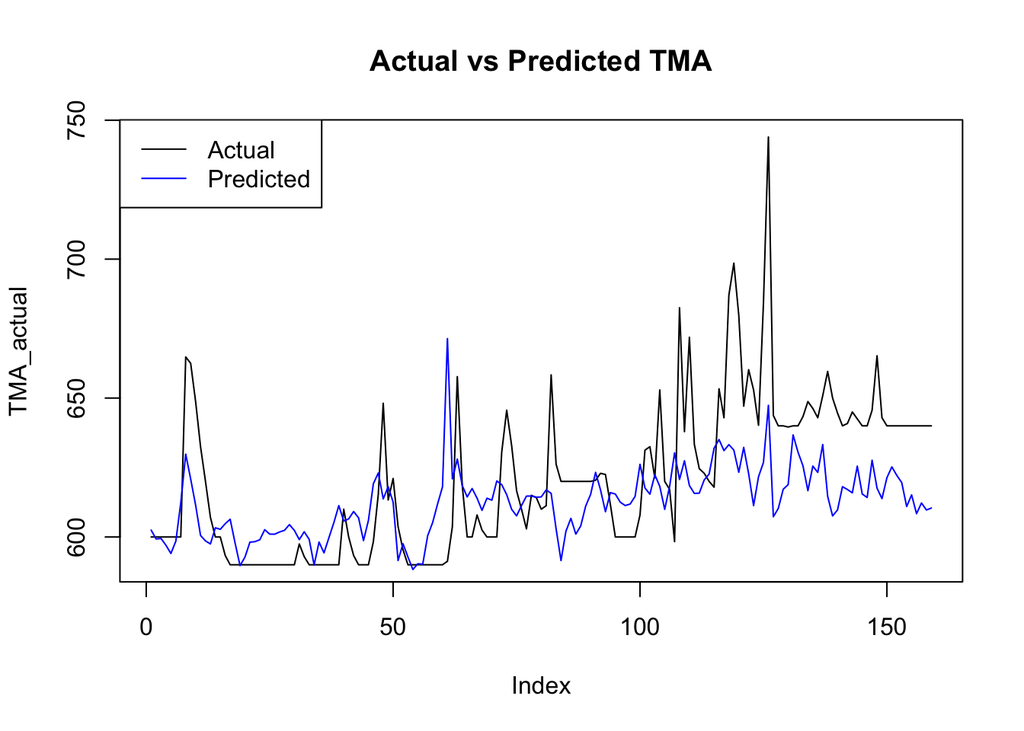

```r
plot(TMA_actual, type = "l", col = "black", main = "Actual vs Predicted TMA")
lines(TMA_pred, col = "blue")
legend("topleft", legend = c("Actual", "Predicted"), col = c("black", "blue"), lty = 1)
```

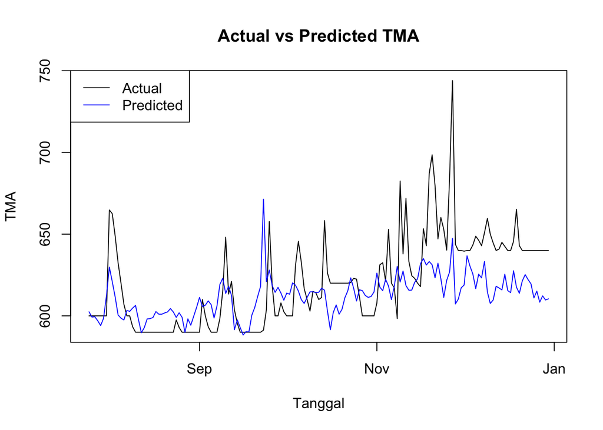

```r
plot(date_seq, TMA_actual, type = "l", col = "black",
     main = "Actual vs Predicted TMA", xlab = "Tanggal", ylab = "TMA")
lines(date_seq, TMA_pred, col = "blue")
legend("topleft", legend = c("Actual", "Predicted"),
       col = c("black", "blue"), lty = 1)
```

```r
# Asumsikan 'aktual_Y_test' adalah nilai Y aktual dari data testing
MAE <- mean(abs(TMA_pred - TMA_actual))
RMSE <- sqrt(mean((TMA_pred - TMA_actual)^2))
# Hitung MAPE jika nilai aktual Y tidak nol
MAPE <- mean(abs((TMA_actual - TMA_pred) / TMA_actual)) * 100

cat("MAE:", MAE, "\n")
```

```
## MAE: 18.03594
```

```r
cat("RMSE:", RMSE, "\n")
```

```
## RMSE: 24.00444
```

```r
cat("MAPE:", MAPE, "%\n")
```

```
## MAPE: 2.834853 %
```

### 7.4.3 Prediksi 2025

```r
data_prediksi_15 <- read_excel("/users/fajrin/Downloads/DATA_SKRIPSI/Data_Jan22_Mar25.xlsx")
data_prediksi_15 <- tail(data_prediksi_15, 120)
data_prediksi_15$Date <- as.Date(data_prediksi_15$Date)
str(data_prediksi_15)
```

```
## tibble [120 × 6] (S3: tbl_df/tbl/data.frame)
##  $ Date: Date[1:120], format: "2025-01-01" "2025-01-02" ...
##  $ TMA : num [1:120] 641 640 640 640 640 ...
##  $ TM  : num [1:120] 24.6 25 25.3 25.1 24.9 ...
##  $ PC  : num [1:120] 5.27 2.45 6.22 6.03 2.63 ...
##  $ RH  : num [1:120] 88 85.2 85.5 86.4 84.6 ...
##  $ WS  : num [1:120] 2.56 1.85 1.75 2.56 2.38 1.82 1.87 2.22 1.64 1.64 ...
```

```r
DPC_15 <- diff(data_prediksi_15$PC, differences = 1)
DTM_15 <- diff(data_prediksi_15$TM, differences = 1)
DRH_15 <- diff(data_prediksi_15$RH, differences = 1)
DWS_15 <- diff(data_prediksi_15$WS, differences = 1)

test_15 <- data.frame(DPC = DPC_15, DTM = DTM_15, DRH = DRH_15, DWS = DWS_15)
```

```r
colnames(test_15) <- c("DPC", "DTM", "DRH", "DWS")
```

```r
coefs <- summary(modelardl)$coefficients
coefs
```

```
##                Estimate Std. Error     t value      Pr(>|t|)
## (Intercept)  0.07490568 0.74754411   0.1002024  9.202057e-01
## l.1.DTMA    -1.46651890 0.03180306 -46.1125109 1.489498e-240
## l.2.DTMA    -0.24857299 0.03542465  -7.0169504  4.421004e-12
## l.3.DTMA    -0.19902488 0.03596208  -5.5342989  4.084481e-08
## l.4.DTMA    -0.11395155 0.03657939  -3.1151846  1.895763e-03
## l.5.DTMA    -0.16066981 0.03620335  -4.4379823  1.019056e-05
## l.6.DTMA    -0.11938737 0.03631123  -3.2878909  1.048004e-03
## l.7.DTMA    -0.09846142 0.03594517  -2.7392114  6.278823e-03
## l.8.DTMA    -0.05481482 0.03466015  -1.5814938  1.141119e-01
## l.9.DTMA     0.02475302 0.03147429   0.7864522  4.318069e-01
## l.1.DPC      0.71956686 0.08739799   8.2332198  6.272925e-16
## l.1.DTM      5.30432405 2.02739535   2.6163245  9.035191e-03
## l.1.DRH      1.23940860 0.33632512   3.6851502  2.420423e-04
## l.1.DWS     -5.57794951 2.28049752  -2.4459354  1.463573e-02
```

```r
intercept <- coefs["(Intercept)", "Estimate"]
b1 <- coefs["l.1.DPC", "Estimate"]
b2 <- coefs["l.1.DTM", "Estimate"]
b3 <- coefs["l.1.DRH", "Estimate"]
b4 <- coefs["l.1.DWS", "Estimate"]
```

```r
test_15$DTMA_pred <- intercept +
  b1 * test_15$DPC +
  b2 * test_15$DTM +
  b3 * test_15$DRH +
  b4 * test_15$DWS
```

```r
test_15$TMA_pred <- NA
test_15$TMA_pred[1] <- data_prediksi_15$TMA[1] + test_15$DTMA_pred[1]

for(i in 2:nrow(test_15)) {
  test_15$TMA_pred[i] <- test_15$TMA_pred[i-1] + test_15$DTMA_pred[i]
}
```

```r
tanggal_prediksi <- seq.Date(from = as.Date("2025-01-01"), by = "day", length.out = nrow(test_15))
```

```r
hasil_prediksi <- data.frame(
  date = tanggal_prediksi,
  TMA_actual = data_prediksi_15$TMA[-1],  # karena differencing
  TMA_pred = test_15$TMA_pred
)
hasil_prediksi
```

```
##           date TMA_actual TMA_pred
## 1   2025-01-01   640.0000 641.0277
## 2   2025-01-02   640.0000 646.7819
## 3   2025-01-03   640.0000 642.2318
## 4   2025-01-04   640.0000 637.5159
## 5   2025-01-05   640.0000 659.4740
## 6   2025-01-06   640.0000 651.4026
## 7   2025-01-07   641.4583 656.7950
## 8   2025-01-08   666.2500 656.8108
## 9   2025-01-09   642.5000 649.8979
## 10  2025-01-10   637.5000 654.3061
## 11  2025-01-11   634.5833 642.2853
## 12  2025-01-12   636.6667 647.0510
## 13  2025-01-13   636.6667 662.4328
## 14  2025-01-14   647.2917 648.9503
```

[output cut: 105 more lines]

```r
# Tentukan nama file Excel
nama_file_excel4 <- "hasil_peramalan.xlsx"

# Tulis data frame ke file Excel
write_xlsx(hasil_prediksi, path = nama_file_excel4)
```

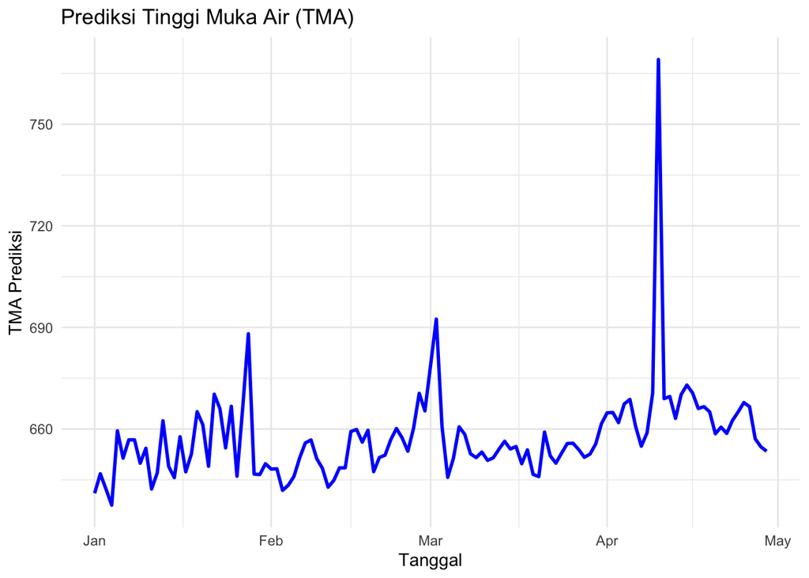

```r
ggplot(hasil_prediksi, aes(x = date, y = TMA_pred)) +
  geom_line(color = "blue", linewidth = 1) +
  labs(
    title = "Prediksi Tinggi Muka Air (TMA)",
    x = "Tanggal",
    y = "TMA Prediksi"
  ) +
  theme_minimal()
```

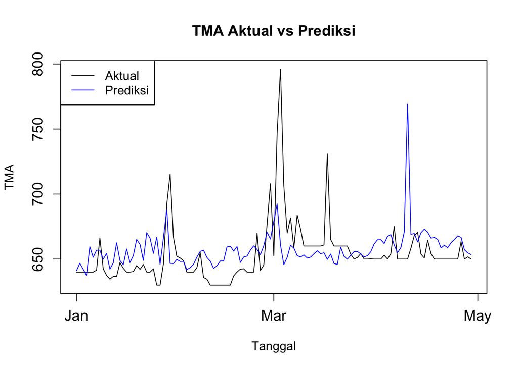

```r
plot(hasil_prediksi$date, hasil_prediksi$TMA_actual, type = "l", col = "black",
     ylab = "TMA", xlab = "Tanggal", main = "TMA Aktual vs Prediksi", cex.axis = 1.2)
lines(hasil_prediksi$date, hasil_prediksi$TMA_pred, col = "blue")
legend("topleft", legend = c("Aktual", "Prediksi"), col = c("black", "blue"), lty = 1)
```

```r
MAE <- mean(abs(hasil_prediksi$TMA_actual - hasil_prediksi$TMA_pred))
RMSE <- sqrt(mean((hasil_prediksi$TMA_actual - hasil_prediksi$TMA_pred)^2))
MAPE <- mean(abs((hasil_prediksi$TMA_actual - hasil_prediksi$TMA_pred) / hasil_prediksi$TMA_actual)) * 100

cat("MAE:", MAE, "\n")
```

```
## MAE: 15.73877
```

```r
cat("RMSE:", RMSE, "\n")
```

```
## RMSE: 25.02491
```

```r
cat("MAPE:", MAPE, "%\n")
```

```
## MAPE: 2.35619 %
```